# Analyzing Travel Data Sets

#### Tharuni Iranjan

##### April 2nd, 2023

##### Purpose

With so many places to visit in the world, its hard to determine where to go on your travels. Using a series of plots and graphs, I want to visually analyze various different country and travel related data sets to determine where to travel to, when and why.

##### Figure 1: Where to Visit

**Description**: This is a geographical map of the world emphasising the most visited countries.  
**Datasets**: [Most Visited Countries of the World](https://www.kaggle.com/datasets/batrosjamali/most-visited-countries-in-the-world), [Latitude and Longitude for Every Country](https://www.kaggle.com/datasets/paultimothymooney/latitude-and-longitude-for-every-country-and-state)

```
##  [1] "France"         "Spain"          "United States"  "China"
##  [5] "Italy"          "Turkey"         "Mexico"         "Thailand"
##  [9] "Germany"        "United Kingdom"
```

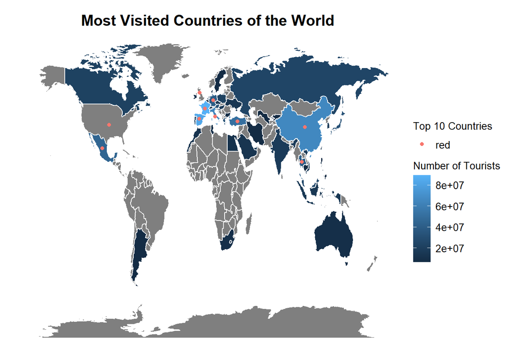

**Findings**: This graph tells us that Europe is a highly visited area, along with parts of Asia and North America. In red I have dots to represent the top 10 most visited countries, which all seem to be in the northern hempisphere.

##### Figure 2: Why You Should Visit a Country

**Description**: This is graph uses facet_wrap to figure out the correlation between different factors and the number of visits a country gets.  
**Datasets**: [Most Visited Countries of the World](https://www.kaggle.com/datasets/batrosjamali/most-visited-countries-in-the-world), [Cost of Living Index](https://www.kaggle.com/datasets/ankanhore545/cost-of-living-index-2022), [World Crime Index](https://www.kaggle.com/datasets/ahmadjalalmasood123/world-crime-index), [World Sanitation & Health](https://www.kaggle.com/datasets/navinmundhra/world-sanitation?select=Basic+and+safely+managed+drinking+water+services.csv)

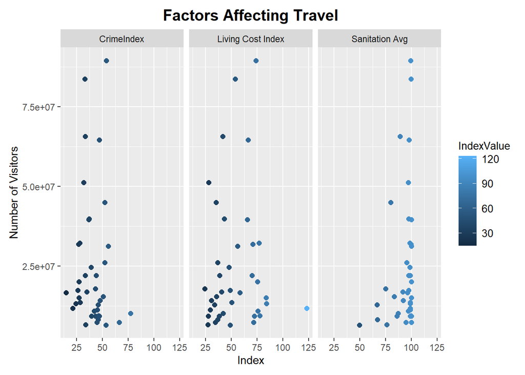

**Findings**: This graph tells us that living costs, safety, and the overall sanitation level play role in whether people visit a country or not. For living cost, we can see most of the data residing to the left. This means that lower costs is corrleated to higher travel rates. Countries in the mid-range on the safety index seem to have the highest travel rate. Finally, we can see that a country must be very clean for higher travel rates.

##### Figure 3: When to Travel within America

**Description**: This is graph compares the price of travel to different quaters of the year to conclude when the best time of travel is for domestic flights in America.  
**Datasets**: [Top 1000 City-Pair Markets](https://data.transportation.gov/Aviation/Consumer-Airfare-Report-Table-2-Top-1-000-City-Pai/wqw2-rjgd)

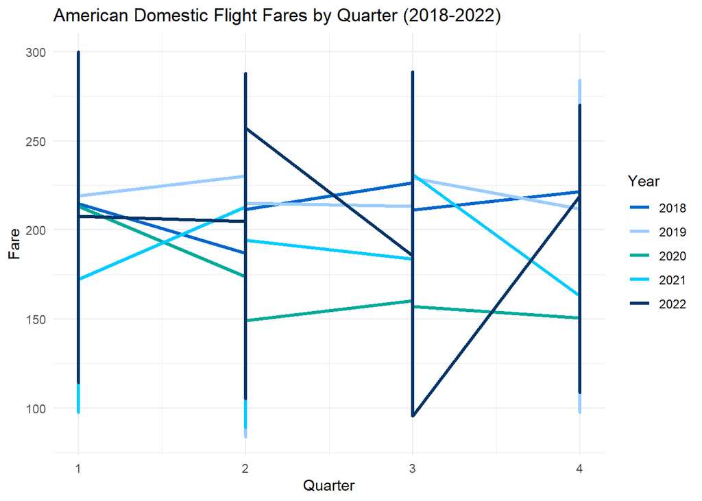

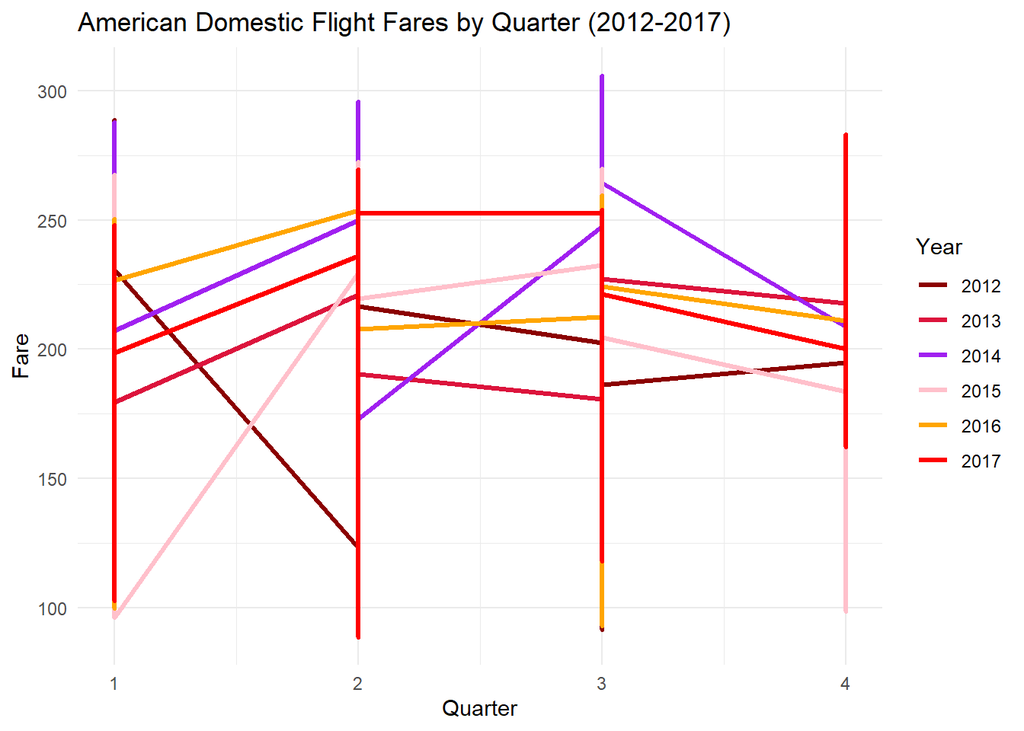

**Findings**: Due to COVID-19 travelling has been unpredictable the past 5 years. You can see fare prices drop by the second quarter of 2020, which is when a global pandemic was declared. However, if we look at pricing 4 years before the pandemic, there is a little more consistency. You can notice flight fares start low at the start of the first quarter and slowly increase into the second. Second quarter remains fairly consistent, whereas in the third you can see a steady decline in price as you enter the final quarter. Based off this information, someone planning to travel within America, should consider booking for during the end of fourth quarter continuing to the start of first quarter.

##### Figure 4: Where to Stay in Thailand

**Description**: One place from the top visited countries that I wanted tour myself is Thailand. There are so many places to stay, it’s hard to choose the best. Using this data set, I want to make a bar plot to help me visualize the best resort for what I am looking for.  
**Dataset**: [Thailand Resort Dataset](https://www.kaggle.com/datasets/aakashshinde1507/resorts-in-thailand)

```
## [1] "Bananas Resort & Restaurant" "Lanta Local Hut"
## [3] "Flower Power Farm Village"   "Rainbow House Resort"
## [5] "Happy Resort Bandung"
```

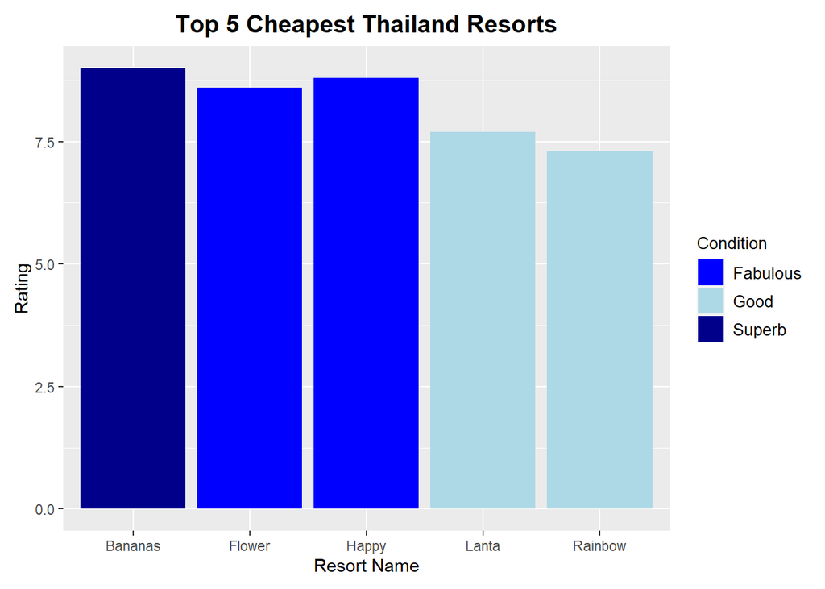

##### Limitations

The size requirement of datasets, and the number of openly available data regarding this subject matter is fairly limited. Further research and development of data sets could help provide analysis on questions like where to travel, when and why can be answered more easily and accurately.